# Method For Acquiring and Comparing Spatially Explicit Measurements of Sun-induced Flourescence on the Ground

Metadata: how is data organized and stored?

[figure not shown]

### Data sources

This analysis used one main dataset consisting of Sun-induced fluorescence (SIF) obseravations collected on 1-2.08.2018 inside a sugar beet field. The measurements were performed using FLOX - a field spectroscopy device manufactured by [JB Hyperspectral](https://www.jb-hyperspectral.com/). For more information about the actual data acquisition procedure on the groud, sensor setup, and the study field see Methods chapter.

The dataset consist of SIF measurements over six locations along one transect. The transect was measured twice in one day - in the morning and early afternoon hours. After processing the raw DN from the FLOX using the provided processing algorythm, the output file consist of the following variables.

```r
library(tidyverse)
library(readxl)
meta <- list()
meta[["flox"]] <- read_excel("data/meta.xlsx", sheet = "flox")
```

### FLOX variables

```r
table1 <- knitr::kable(meta$flox, caption = "Metatable of FLOX variables with units and description", format = "html")
kableExtra::column_spec(table1, 1:2, width = "4cm", bold = TRUE)
```

Metatable of FLOX variables with units and description

| Variable | Units | Description |
| --- | --- | --- |
| doy.dayfract | [unitless] | Local time and date in decimal format, e.g 179 is the 00.00 o’clock on 179th day of the calendar year, noon is 179.5 and so on. |
| datetime [UTC] | [date] | UTC Time downloaded from GPS |
| SZA | [degrees] | Sun Zenith Angle, calculated from UTC time |
| Lat | [degrees] | Latitude downloaded from GPS |
| Lon | [degrees] | Longituted downloaded from GPS |
| Incoming at 750nm | [W m-2nm-1sr-1] | Incommin radiation at 750 nm |
| Reflected 760 | [W m-2nm-1sr-1] | Reflected radiation at 760 nm |
| Reflected 687 | [W m-2nm-1sr-1] | Reflected radiation at 687 nm |
| Reflectance 750 | [unitless] | Reflectance (unitless) |
| Reflectance 760 | [unitless] | Reflectance (unitless) |
| temp1 | [C] | Temperature readings inside box, for more info contact JB |
| temp2 | [C] | Temperature readings inside box, for more info contact JB |
| temp3 | [C] | Temperature readings inside box, for more info contact JB |
| temp4 | [C] | Temperature readings inside box, for more info contact JB |
| h1 | [%] | Relative Humidity |
| h2 | [%] | Relative Humidity |
| E_stability | [%] | Percentage difference between first and last PAR readings for measurement cycle from QE Pro. Shows how dynamic Ilumination conditions during measurement are |
| sat value L | [unitless] | Saturation value for reflected radiation from QE Pro |
| sat value E | [unitless] | Saturation value for incoming radiation at begining of measurement cycle from QE Pro |
| sat value E2 | [unitless] | Saturation value for incoming radiation at end of measurement cycle from QE Pro |
| SIF_A_ifld | [mW m-2nm-1sr-1] | Sun induced fluorescence values for 760 nm retrieved by iFLD |
| SIF_B_ifld | [mW m-2nm-1sr-1] | Sun induced fluorescence values for 687 nm retrieved by iFLD |
| SIF_A_sfm | [mW m-2nm-1sr-1] | Sun induced fluorescence values for 760 nm retrieved by Spectral Fitting Method (Cogliatti 2015) |
| SIF_B_sfm | [mW m-2nm-1sr-1] | Sun induced fluorescence values for 687nm retrieved by Spectral Fitting Method (Cogliatti 2015) |
| A_sfm_conv | [unitless] | Convolution coeficient for SFM |
| B_sfm_conv | [unitless] | Convolution coeficient for SFM |
| NDVI | [unitless] | Vegetation index related to overall greennes , higher values normally mean more greeen biomass (but it saturates at higher levels of biomass) |
| PRI | [unitless] | Photochemical reflectance index |
| MTCI | [unitless] | MERIS terrestrial chlorophyll index |
| SR | [unitless] | Simple ratio |
| EVI | [unitless] | Enhanced vegetation index |
| REP | [unitless] | Red edge inflexion point |
| TCARI | [unitless] | Transformed chlorophyll absorption reflectance index |
| REDCl | [unitless] | Red edge crust index |
| mCRI | [unitless] | Modified carotenoid reflectance index |
| EPAR | [unitless] | Inclomming PAR |
| LPAR | [unitless] | Reflected PAR |
| E_stability full | [%] | Percentage difference between first and last PAR readings for measurement cycle from FLAME. Shows how dynamic Ilumination conditions during measurement are |
| sat value L full | [unitless] | Saturation value for reflected radiation from FLAME |
| sat value E full | [unitless] | Saturation value for incoming radiation at begining of measurement cycle from FLAME |
| sat value E2 full | [unitless] | Saturation value for incoming radiation at end of measurement cycle from FLAME |

### Auxilary variables

To that table we appended variables designating ID for each location, and weather it was the morning or the afternoon measurement, the LAI measured with Sunscan.

```r
meta[["aux"]] <- read_excel("data/meta.xlsx", sheet = "aux")
table2 <- knitr::kable(meta$aux, caption = "Metatable of additional variables added by user", format = "html")
kableExtra::column_spec(table2, 1, width = "3cm", bold = TRUE)
```

Metatable of additional variables added by user

| Variable | Description |
| --- | --- |
| unique.loc | Unique location (independend of when taken) |
| loc1 | Timing (1 for morning, 2 for afternoon) |
| n.obs | Number of measurement cycles per location |
| lai | Leaf area index measured using Sunscan |

### Overview

Here we produce a plot showing the average SIF 760 value for each location (in the morning and in the afternoon) and the transect inside the sugar beet field.

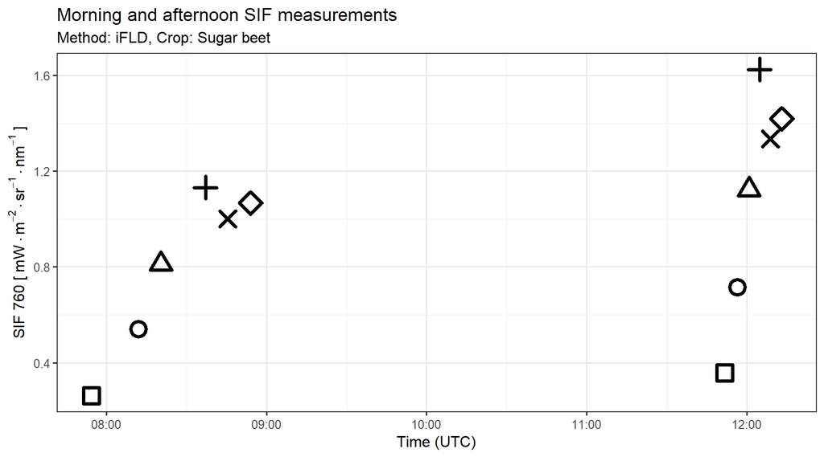

```r
# plot SIF vs. Time
p1 <- ggplot() +
  geom_point(data = mobile.sb5, aes(x = `datetime [UTC]`,
                                y = SIF_A_ifld,
                                shape=unique.loc,
                                size = 2, stroke =2)) +
    scale_shape_manual(values=seq(0,18)) +
    xlab("Time (UTC)") +
    ylab(expression("SIF 760 ["~mW%.%m^{-2}%.%sr^{-1}%.%nm^{-1}~"]")) +
  theme_bw(base_size = 12) +
    theme(legend.position="none") +
    labs(title = "Morning and afternoon SIF measurements", subtitle = "Method: iFLD, Crop: Sugar beet")
p1
```

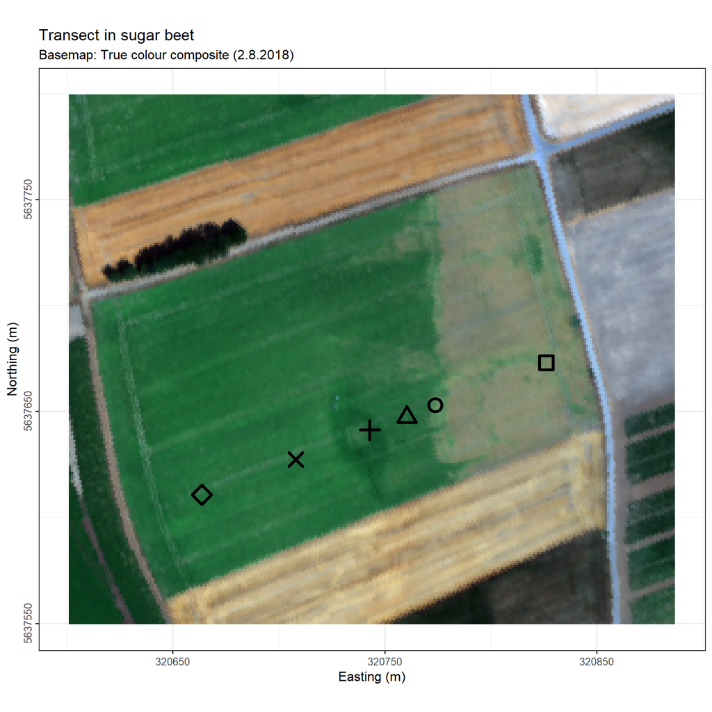

Coordinate reference system: EPSG:32632, Datum:WGS 84, Projection:UTM Zone 32N

```r
#raster image as basemap
library(raster)
icc <- raster::stack("data/icos_color_composites")
selras.trcol <- icc[[3:1]]
selras.facol <- icc[[4:2]]
# if needed rename
# names(selras) <- substr(names(selras), 13, 24)
# cut to sugar beet extend
win2 <-
  raster::extent(320600.6, 320900.0, 5637550, 5637800) # the sugar beet field
icos.ras <- raster::crop(selras.facol, win2)
icos.sb <- as.data.frame(as(icos.ras, "SpatialPixelsDataFrame"))

# ggplot map using rggbplot
m1 <- rggbplot(raster::crop(selras.trcol, win2), npix = 5000000)
m2 <- m1 +
  geom_point(data = mobile.sum,
             aes(magvar, geoidheigh, shape=unique.loc, fill = "black", size = 2, stroke =2)) +
  scale_shape_manual(values=c(0:5)) +
  labs(x = "Easting (m)", y = "Northing (m)", title= "Transect in sugar beet", subtitle = "Basemap: True colour composite (2.8.2018)") +
  theme(legend.position="bottom") +
  scale_y_continuous(breaks =
                       seq(extent(icos.sb)@ymin,extent(icos.sb)@ymax,by=100)) +
  scale_x_continuous(breaks =
                       seq(extent(icos.sb)@xmin + 48.5, extent(icos.sb)@xmax, by=100)) +
  coord_equal() +
  theme_bw(base_size = 12) +
  theme(legend.position = "none", axis.text.y = element_text(angle = 90, hjust = 0.5))

m2
```